# Coursera Machine Learning Assignment

KVdG

May 27 2018

This is a re-submission. I noticed I made a mistake and redid part of my work. My apologies if you - as a reviewer - see my work twice.

# Background

Using devices such as Jawbone Up, Nike FuelBand, and Fitbit it is now possible to collect a large amount of data about personal activity relatively inexpensively. These type of devices are part of the quantified self movement – a group of enthusiasts who take measurements about themselves regularly to improve their health, to find patterns in their behavior, or because they are tech geeks. One thing that people regularly do is quantify how much of a particular activity they do, but they rarely quantify how well they do it. In this project, your goal will be to use data from accelerometers on the belt, forearm, arm, and dumbell of 6 participants. They were asked to perform barbell lifts correctly and incorrectly in 5 different ways. More information is available from the website here: http://groupware.les.inf.puc-rio.br/har (see the section on the Weight Lifting Exercise Dataset).

# Some information about the data set

(The text below is copied from the HAR website.)

Six young health participants were asked to perform one set of 10 repetitions of the Unilateral Dumbbell Biceps Curl in five different fashions: exactly according to the specification (Class A), throwing the elbows to the front (Class B), lifting the dumbbell only halfway (Class C), lowering the dumbbell only halfway (Class D) and throwing the hips to the front (Class E).

Read more: http://web.archive.org/web/20161224072740/http:/groupware.les.inf.puc-rio.br/har#ixzz5GisaTutu

# Data Modelling Approach

Because the test set that is provided is one without the to be predicted variable, we can’t use this set to estimate accuracy of our models. We need to **cross-validate** with a validation data set that we create ourselves. On that validation set we calculate the **out of sample error** estimates. For multiple categories, we could use **overall accuracy** may be used.

1. data are loaded and prepared
2. data are splitted in a training and validation set
3. for each model
   - build a model on the training set
   - calculate training performance
   - calculate *out of sample error* estimates on the validation set
4. compare models and select the best
5. predict with the best model using the provided *test data set*

# Data Loading and Preparation

```r
f1 <- "https://d396qusza40orc.cloudfront.net/predmachlearn/pml-training.csv"
f2 <- "https://d396qusza40orc.cloudfront.net/predmachlearn/pml-testing.csv"
pml_training.csv <- read.csv(file = f1, header = TRUE )
pml_testing.csv <- read.csv(file = f2, header = TRUE )
rm(f1, f2)
```

```r
## remove columns with subject variables (the first 7)
training <- pml_training.csv[ , -c(1:7) ]
testing <- pml_testing.csv[ , -c(1:7) ]

## remove columns with NAs
NA_training <- which(colSums(is.na(training)) == 0)
NA_testing <-  which(colSums(is.na(testing)) == 0)

# There are more columns with NAs in the test set, hence we take this list
# to clean both train and test set
training <- training[, NA_testing]
testing <- testing[, NA_testing]
```

# Model Building

## Cross validation sets

```r
set.seed(1234)
inTrain = createDataPartition(training$classe, p = 0.70)[[1]]
training = training[ inTrain,]
validation = training[-inTrain ,]
dim(training); dim(validation)
```

```
## [1] 13737    53
```

```
## [1] 4124   53
```

## Trees Model

### Build model on training set

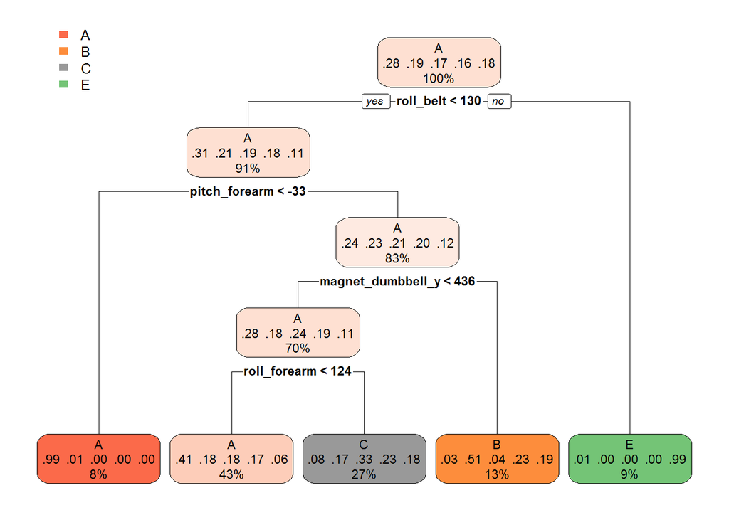

```r
fit_tree <- train(classe ~ . , method = "rpart", data = training)
rpart.plot(fit_tree$finalModel)
```

### Performance on the training set

```r
confusionMatrix(fit_tree)
```

```
## Bootstrapped (25 reps) Confusion Matrix
##
## (entries are percentual average cell counts across resamples)
##
##           Reference
## Prediction    A    B    C    D    E
##          A 22.4  6.4  5.1  4.7  1.8
##          B  1.4  7.9  1.8  3.7  3.5
##          C  3.5  4.2 10.0  5.1  3.7
##          D  0.9  0.8  0.5  2.8  0.8
##          E  0.2  0.0  0.0  0.0  8.6
##
##  Accuracy (average) : 0.5165
```

### Performance on the validation set

```r
pred_tree <- predict(fit_tree, newdata = validation)
cm_tree_val <- confusionMatrix(reference = validation$classe, data = pred_tree)
cm_tree_val$overall[1]
```

```
##  Accuracy
## 0.5002425
```

The **out of sample error estimate** for the tree model is 0.5

## RandomForest with parallel processing

### Prepare for parallel processing

```r
library(doParallel)
library(parallel)
detectCores(); detectCores(logical = FALSE)
```

```
## [1] 4
```

```
## [1] 2
```

### Build Model on training set

```r
cluster <- makeCluster(detectCores()-1) # convention to leave 1 core for OS
registerDoParallel(cluster)

fitControl <- trainControl(method = "cv", number = 5, allowParallel = TRUE)

fit_rf <- train(classe ~ . , method = "rf", data = training, trControl = fitControl)

stopCluster(cluster)
registerDoSEQ()

confusionMatrix(fit_rf$finalModel$predicted, training$classe)
```

[output not shown]

### Performance on the training set

```r
confusionMatrix(fit_rf)
```

```
## Cross-Validated (5 fold) Confusion Matrix
##
## (entries are percentual average cell counts across resamples)
##
##           Reference
## Prediction    A    B    C    D    E
##          A 28.4  0.1  0.0  0.0  0.0
##          B  0.0 19.2  0.1  0.0  0.0
##          C  0.0  0.0 17.3  0.2  0.0
##          D  0.0  0.0  0.0 16.2  0.0
##          E  0.0  0.0  0.0  0.0 18.3
##
##  Accuracy (average) : 0.9944
```

### Performance on the validation set

```r
pred_rf <- predict(fit_rf, newdata = validation)
cm_rf_val <- confusionMatrix(reference = validation$classe, data = pred_rf)
cm_rf_val$overall[1]
```

```
## Accuracy
##        1
```

## Compare models and select the best

From the above it is clear the the Random Forest model is the best. Hence we will use this model to predict.

# Predict with the best model: Random Forest Based

```r
# print(fit_rf$finalModel)

pred_rf <- predict(fit_rf, newdata = testing)
print(pred_rf)
```

```
##  [1] B A B A A E D B A A B C B A E E A B B B
## Levels: A B C D E
```

# Conclusion

Several models were tested, two were selected for reporting as they provide insight. The tree model has limited accuracy, while the random forest model is very good in predicting.